# Dynamic PINNs (3): Solving a Non-Linear ODE across a Range of Pendulum Lengths with a Parameterised PINN

This notebook extends the fixed-length PINN to a parameterised setting where the pendulum length L is treated as a variable input. A single network learns the solution for any L in [0.5, 1.5] m, eliminating the need to retrain for each design point. We compare the parameterised loss functions, training loop, and predictions against numerical ground truth at multiple L values.

pytorch

SciML

PINN

Author

Mei-Chin Pang

Published

May 9, 2026

```python
import time

import matplotlib.pyplot as plt
import numpy as np
from scipy.integrate import odeint
from tqdm import tqdm

plt.rcParams["text.usetex"] = True
```

```python
import warnings
import torch
import torch.nn as nn

# Suppress Intel Iris Xe "not officially supported" warning
warnings.filterwarnings(
    "ignore",
    message=".*detected GPU.*not officially supported by PyTorch XPU.*")

# Define the GPU type ("cuda" for NVIDIA GPUs, "xpu" for Intel GPUs)
gpu_type = "xpu"

if gpu_type == "cuda":
    device = torch.device("cuda" if torch.cuda.is_available() else "cpu")
elif gpu_type == "xpu":
    device = torch.device("xpu" if torch.xpu.is_available() else "cpu")
else:
    raise ValueError("Invalid GPU type. Use 'cuda' or 'xpu'.")

print(f"Using device: {device}")
```

```
Using device: cpu
```

# Parameterised PINN for Non-Linear ODEs

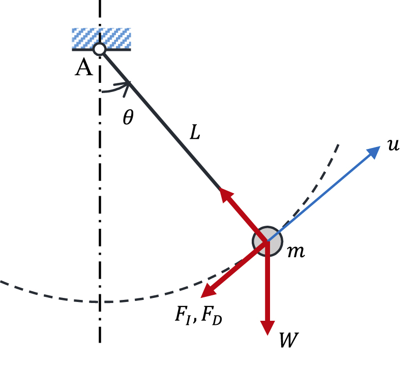

Non-Linear ODE for a Damped Pendulum

In the previous PINN example, we have evaluated a non-linear ODE based on a scenario from a damped pendulum of fixed length $L$ and mass $m$, which swings under gravity $g$. Air resistance introduces a damping force proportional to angular velocity. The angle from vertical, $\theta(t)$, obeys the following equation of motion:

$$\boxed{\frac{d^2\theta}{dt^2} + \frac{b}{m}\,\underbrace{\frac{d\theta}{dt}}_{=\,\omega} + \underbrace{\frac{g}{L}}_{=c_p}\sin\!\bigl(\theta(t)\bigr) = 0}$$

where $b$ is the damping coefficient. We define $\omega = d\theta/dt$ and $c_p = g/L$ for convenience reason. In this example, we will look at parameterised PINN, where $L$ is treated as an unknown parameter and the network learns $\hat{\theta}(t, L)$ for any $L \in [0.5, 1.5]$ m. The equation remains the same, but what changes is that $L$ is now a flexible parameter.

**ImportantWhy do we need a single model over a range of $L$ values?**

Training a separate PINN for each $L$ value would require running a full training loop (thousands of epochs) for every design point, which is expensive and inefficient. A single parameterised PINN is trained once and can then be queried instantly for any $L$ in the range. This is particularly valuable in design optimisation, sensitivity analysis, or real-time control applications where many $L$ values must be evaluated quickly.

# Formulate Parameterised PINN Loss Functions for Non-Linear ODE

## Term 1: Initial Condition (IC)/Boundary Condition (BC) Loss

$\mathcal{L}_\text{IC}$ penalises the network for predicting the wrong starting angle or starting angular velocity at $t=0$. It is purely a boundary/initial constraint.

**Constant $L$ parameter in the ODE-model**

With a fixed pendulum length, the network only takes $t$ as input, so there is a single IC to satisfy:

$$\mathcal{L}_\text{IC} = \left(\hat{\theta}(0) - \theta_0\right)^2 + \left(\frac{d\hat{\theta}}{dt}\bigg|_{t=0} - \omega_0\right)^2$$

**Flexible $L$ parameter in the ODE-model**

Because the network now takes two inputs $(t, L)$, the starting conditions must hold for all $L$ values in the training range. A single BC check at one $L$ would leave the network free to predict wrong initial angles at other lengths. The sum over $N_\text{bc}$ sampled values of $L_j$ ensures the network learns to start at $\theta_0$ with velocity $\omega_0$ regardless of which pendulum length is queried:

$$\mathcal{L}_\text{BC} = \frac{1}{N_\text{bc}}\sum_{j=1}^{N_\text{bc}}\left[\left(\hat{\theta}(0, L_j) - \theta_0\right)^2 + \left(\frac{d\hat{\theta}}{dt}\bigg|_{t=0,\, L_j} - \omega_0\right)^2\right]$$

**NoteInitial condition vs. boundary condition**

With a fixed $L$, the network input is one-dimensional ($t$ only), so the constraint at $t = 0$ is a standard **initial condition (IC)**: the solution must start at the prescribed angle and velocity at a single point in time.

When $L$ becomes a flexible input, the network operates over a two-dimensional domain $(t, L)$. The constraint at $t = 0$ must now be enforced for every $L$ in the training range $[L_\text{min}, L_\text{max})$, forming a line (or boundary) in the $(t, L)$ plane rather than a single point. This makes it a **boundary condition (BC)** in the broader sense: we are prescribing values along the $t = 0$ boundary of the 2D input space for all sampled $L_j$ values.

## Term 2: Physics (Residual) Loss

**NoteHow to formulate the physics loss from a given ODE**

**Step 1: Start from the governing ODE.** For the damped pendulum the equation of motion is

$$\boxed{\frac{d^2\theta}{dt^2} + \frac{b}{m}\,\frac{d\theta}{dt} + \frac{g}{L}\sin\!\bigl(\theta(t)\bigr) = 0}$$

**Step 2: Replace the exact solution with the network prediction.** Substitute $\theta \to \hat{\theta}$ (the neural-network output) and compute every derivative via automatic differentiation. This gives the **residual**:

$$r(t) = \frac{d^2\hat{\theta}}{dt^2} + \frac{b}{m}\,\frac{d\hat{\theta}}{dt} + \frac{g}{L}\sin\!\bigl(\hat{\theta}(t)\bigr)$$

If $\hat{\theta}$ were the true solution, $r(t)$ would be exactly zero everywhere. In practice it is not, so $r(t)$ measures how badly the network violates the physics at each point.

**Step 3: Define the physics loss as the mean squared residual.** Evaluate $r(t)$ at a set of collocation points $\{t_i\}_{i=1}^{N_\text{phys}}$ and penalise non-zero residuals:

$$\mathcal{L}_\text{phys} = \frac{1}{N_\text{phys}}\sum_{i=1}^{N_\text{phys}} r(t_i)^2$$

No numerical ODE solver is involved: the ODE is enforced purely through this loss term, and the physics is fully satisfied when $\mathcal{L}_\text{phys} \to 0$.

**Constant $L$ parameter in the ODE-model**

With a fixed $L$, the coefficient $c_p = g/L$ is a constant computed once before training. The residual only depends on $t$:

$$\mathcal{L}_\text{phys} = \frac{1}{N_\text{phys}}\sum_{i=1}^{N_\text{phys}} \left[\frac{d^2\hat{\theta}}{dt^2}(t_i) + \frac{b}{m}\,\frac{d\hat{\theta}}{dt}(t_i) + c_p\sin\!\bigl(\hat\theta(t_i)\bigr)\right]^2$$

where $\mathcal{L}_\text{phys}$ is the physics loss that penalises the network for violating the equation of motion at the collocation points.

**Flexible $L$ parameter in the ODE-model**

When $L$ varies, $c_p$ can no longer be precomputed as a single constant. Instead, each collocation point carries its own $L_i$, and the ratio $g/L_i$ must be evaluated per point inside the residual. The network predictions $\hat{\theta}$, $d\hat{\theta}/{dt}$, and $d^2\hat{\theta}/{dt^2}$ now all depend on both $t_i$ and $L_i$:

$$\mathcal{L}_\text{phys} = \frac{1}{N_\text{phys}}\sum_{i=1}^{N_\text{phys}} \left[\frac{d^2\hat{\theta}}{dt^2}(t_i, L_i) + \frac{b}{m}\,\frac{d\hat{\theta}}{dt}(t_i, L_i) + \frac{g}{L_i}\sin\!\bigl(\hat\theta(t_i, L_i)\bigr)\right]^2$$

This ensures the ODE is enforced across the full $(t, L)$ domain, not just for one pendulum length.

## Total Loss

$$\mathcal{L} = \lambda_\text{BC}\,\mathcal{L}_\text{BC} + \lambda_\text{phys}\,\mathcal{L}_\text{phys}$$

**NoteUnderstanding parameterised PINN loss functions**

**(1) Why does $c_p = g/L_i$ vary at every collocation point?** Each collocation point $(t_i, L_i)$ represents a different physical pendulum (a different length). The ODE must be satisfied correctly for each one, and $c_p = g/L_i$ is what makes the ODE specific to that length. Using a fixed $c_p$ for all points would only enforce the physics for one particular $L$, defeating the purpose of parameterisation.

**(2) Why do we need many $L$ values in the IC loss, not just one?** The network must satisfy $\hat{\theta}(0, L) = \theta_0$ for **every** $L$ in the training range, not just one. If we only enforced the IC at a single $L$ value, the network could satisfy the initial conditions perfectly at that $L$ while failing to start correctly for other lengths. Sampling many $L$ values at $t=0$ ensures the IC constraint is broadcast across the entire parameter space.

**(3) Why are more collocation points needed here (2,000) compared to the previous example (500)?** The training domain is now 2D - $(t, L) \in [0,1] \times [0.5, 1.5]$ - which is a much larger space to cover than the 1D time domain in the previous example. To ensure the physics is well-enforced throughout this 2D space, we need proportionally more collocation points. With too few, large regions of the parameter space would have no physics supervision and the network could learn wrong solutions there.

**(4) Why can the network predict at $L = 1.23$ m even though it was never explicitly trained on that exact value?** The PINN learns a smooth, continuous mapping $\hat{\theta}(t, L)$. During training, collocation points sample the $(t, L)$ space randomly, covering the range $L \in [0.5, 1.5]$ densely but not exhaustively. Because the network weights define a smooth function and the physics loss enforces the ODE everywhere it is sampled, the learned solution interpolates naturally to any $L$ within the training range, including $L = 1.23$ m. This is interpolation within the training distribution.

# Building and Configuring the PINN

## Model architecture

- **Two-element input:** at each forward pass, the network receives a pair $(t_i, L_i)$, the time value and the pendulum length at that collocation point, concatenated into a 2-element input vector. During evaluation, all time points share the same fixed $L$ value (the chosen test length).
- **Tanh activation is still required:** we still need to compute $d^2\hat{\theta}/{dt^2}$ via automatic differentiation with respect to $t$, which requires the network to be twice differentiable in $t$. Tanh is infinitely smooth, so this is satisfied. We do *not* differentiate with respect to $L$ (it is a parameter, not a variable to differentiate through), but smooth derivatives in $t$ remain essential.
- **Minimal capacity change:** adding one input neuron to the first layer increases the parameter count by only 64 weights (one extra weight per hidden neuron in the first layer) out of roughly 8,000+ total parameters. This is less than a 1% increase. The network’s representational capacity is determined by the width (64) and depth (3 layers), not by whether the input is 1D or 2D.

## Define the Model Parameters

```python
t_start = 0.0
t_end   = 1.0

g  = 9.81          # gravitational acceleration (m/s^2)
L  = 1.0           # pendulum length (m)
m  = 1.0           # mass (kg)
b  = 0.01          # damping coefficient (kg/s)

# Initial angle (radians)
theta0 = 1.0

# Initial angular velocity
# starts from rest, so angular velocity is zero
omega0 = 0.0

# L is now a range, not a single value
# minimum pendulum length (metres)
L_min  = 0.5

# maximum pendulum length (metres)
L_max  = 1.5
```

## Network architecture

We use a fully connected (dense) feedforward neural network with **tanh** activations. The architecture has three parts:

| Layer block | Abbreviation | Description |
| --- | --- | --- |
| `fcs` | **f**ully **c**onnected **s**tart | Input layer: maps inputs to `N_NEURON` neurons, followed by tanh. |
| `fch` | **f**ully **c**onnected **h**idden | Hidden layers: `N_LAYERS - 1` identical blocks, each a linear layer + tanh. |
| `fce` | **f**ully **c**onnected **e**nd | Output layer: a single linear layer that maps from `N_NEURON` to the single output $\hat{\theta}(t)$. |

Here we use `N_NEURON = 64` and `N_LAYERS = 3`, giving two hidden blocks and one input block (three tanh layers total).

Each `nn.Linear(in, out)` layer computes $y = xW^\top + b$, where $W$ is an `out` $\times$ `in` weight matrix and $b$ is a bias vector of length `out`. For example, `nn.Linear(1, 64)` takes the single scalar input $t$ and produces a 64-dimensional vector, one value per hidden neuron.

## Number of layers

`N_LAYERS` represents the total number of layers **with activations**. The `fcs` block already provides the first activated layer, so `fch` only needs to create the remaining `N_LAYERS - 1`. With `N_LAYERS = 3`:

| Block | Layers created | Tanh activations |
| --- | --- | --- |
| `fcs` | 1 (input → 64) | 1 |
| `fch` | `N_LAYERS - 1` = 2 (64 → 64 each) | 2 |
| `fce` | 1 (64 → output) | 0 (no activation) |
| **Total** | - | **`N_LAYERS`** = 3 |

```python
class FullyConnectedNN(nn.Module):
    def __init__(self, N_INPUT, N_OUTPUT, N_NEURON, N_LAYERS):
        super().__init__()

        # Using Tanh activation
        activation = nn.Tanh

        # First layer: input to hidden layers
        # Using nn.Sequential to stack layers and activations
        self.fcs = nn.Sequential(
            nn.Linear(N_INPUT, N_NEURON), activation())

        # Hidden layers: N_LAYERS - 1 hidden layers
        # Since fcs already provides one, fch only needs to add the
        # remaining N_LAYERS - 1.
        self.fch = nn.Sequential(*[
            nn.Sequential(nn.Linear(N_NEURON, N_NEURON), activation())
            for _ in range(N_LAYERS - 1)])

        # Output layer: hidden to output
        self.fce = nn.Linear(N_NEURON, N_OUTPUT)

    # Forward pass through the network
    def forward(self, x):
        x = self.fcs(x)
        x = self.fch(x)
        x = self.fce(x)
        return x
```

## Training Setup

The network is instantiated with `N_INPUT = 2` (instead of 1) so the first linear layer accepts the concatenated vector $(t, L)$. Everything else in the architecture stays the same.

### Collocation points (physics loss)

We sample **2,000** random $(t, L)$ pairs from the 2D domain $[0, t_\text{end}] \times [L_\text{min}, L_\text{max})$. Both $t$ and $L$ are drawn uniformly. Only `t_phys` has `requires_grad=True` because we differentiate $\hat{\theta}$ with respect to $t$ (not $L$) when computing the ODE residual.

### Boundary condition points (IC loss)

We sample **500** random $L$ values from $[L_\text{min}, L_\text{max})$ and pair each with $t = 0$. This ensures the initial conditions $\hat{\theta}(0, L_j) = \theta_0$ and ($d\hat{\theta}/{dt})|_{t=0,\, L_j} = \omega_0$ are enforced across the full range of pendulum lengths, not just at a single $L$.

**NoteUniform sampling from $[a, b]$**

The notation $[0, 1)$ is called a **half-open interval**. The square bracket $[$ means the left endpoint is **included**, and the round parenthesis $)$ means the right endpoint is **excluded**. So $[0, 1)$ contains every number $x$ satisfying $0 \le x < 1$: zero is a possible value, but one is not. This is exactly the range produced by `torch.rand`.

Both `L_phys` and `L_bc` are generated using the pattern:

```python
L_phys = torch.rand(N, 1) * (L_max - L_min) + L_min
L_bc = torch.rand(N, 1) * (L_max - L_min) + L_min
```

This samples uniformly from $[L_\text{min}, L_\text{max})$ in three steps:

1. `torch.rand(N, 1)` produces $N$ random values in $[0, 1)$.
2. Multiplying by $(L_\text{max} - L_\text{min})$ scales the range to $[0,\, L_\text{max} - L_\text{min})$.
3. Adding $L_\text{min}$ shifts it to $[L_\text{min},\, L_\text{max})$.

In general: $x = \text{rand}() \times (b - a) + a$ to sample uniformly from $[a, b)$.

`t_phys` uses the same idea but with $a = 0$:

```python
t_phys = torch.rand(N_phys, 1, device=device) * t_end
```

When $a = 0$ the formula simplifies to $x = \text{rand}() \times b$. `torch.rand` gives values in $[0, 1)$, and multiplying by `t_end` scales them to $[0, t_\text{end})$. No shift is needed because the interval already starts at zero.

```python
# Set random seed for reproducibility
torch.manual_seed(42)

# Note: n_input is now 2 to account for (t, L)
n_input   = 2

# n_output is still 1 since we're predicting theta(t, L)
n_output  = 1
n_hidden  = 64
n_layers  = 3
epochs    = 10000
learning_rate = 1e-3

# ----------------------------------------------------------------------------
# Create the PINN model
pinn = FullyConnectedNN(
    n_input,
    n_output,
    n_hidden,
    n_layers).to(device)

# Create the optimiser using Adam algorithm
optimiser = torch.optim.Adam(
    pinn.parameters(),
    lr=learning_rate)

# ----------------------------------------------------------------------------
# Collocation points: randomly sample (t, L) space
N_phys = 2000
# t_phys is sampled uniformly from [0, t_end)
t_phys = torch.rand(N_phys, 1, device=device) * t_end
t_phys.requires_grad_(True)

# L_phys is sampled uniformly from [L_min, L_max)
L_phys = torch.rand(
    N_phys, 1, device=device) * (L_max - L_min) + L_min

# ----------------------------------------------------------------------------
# Boundary points: t=0 for 500 random L values
N_boundary = 500

# L_bc is sampled uniformly from [L_min, L_max)
L_bc = torch.rand(
    N_boundary, 1, device=device) * (L_max - L_min) + L_min

# t_bc is set to 0 for all boundary points
t_bc = torch.zeros_like(
    L_bc, device=device, requires_grad=True)


print(f"Collocation points: {N_phys}   Boundary points: {N_boundary}")
print(f"Training for {epochs} epochs...")
```

```
Collocation points: 2000   Boundary points: 500
Training for 10000 epochs...
```

## Inspecting PINN parameters in the network

`pinn.parameters()` is a generator that yields every learnable tensor (weight matrix or bias vector) in the network. For each parameter tensor `p`:

- `p.shape` shows its dimensions (e.g. `torch.Size([64, 2])` for the first weight matrix, which maps 2 inputs to 64 neurons).
- `p.numel()` returns the total number of scalar values in that tensor (i.e. the product of all dimensions).

`sum(p.numel() for p in pinn.parameters())` adds up the element counts across all tensors to give the total number of trainable parameters in the network.

With `N_INPUT = 2`, `N_NEURON = 64`, `N_LAYERS = 3`, and `N_OUTPUT = 1`, the loop prints eight tensors (one weight matrix and one bias vector per linear layer):

| Block | Layer | Tensor | Shape | Parameters |
| --- | --- | --- | --- | --- |
| `fcs` | `Linear(2, 64)` | weight | $(64 \times 2)$ | 128 |
| - | - | bias | $(64,)$ | 64 |
| `fch[0]` | `Linear(64, 64)` | weight | $(64 \times 64)$ | 4,096 |
| - | - | bias | $(64,)$ | 64 |
| `fch[1]` | `Linear(64, 64)` | weight | $(64 \times 64)$ | 4,096 |
| - | - | bias | $(64,)$ | 64 |
| `fce` | `Linear(64, 1)` | weight | $(1 \times 64)$ | 64 |
| - | - | bias | $(1,)$ | 1 |
| - | - | - | **Total** | **8,577** |

Note that the `fcs` weight matrix has shape $(64, 2)$ rather than $(64, 1)$ because `N_INPUT = 2`. This is the only layer affected by the change from 1D to 2D input, adding just 64 extra weights compared to the single-input PINN (which has $64 \times 1 = 64$ weights in the first layer, totalling 8,513 parameters).

```python
for index, p in enumerate(pinn.parameters(), 1):
    print(f"Layer {index}: {p.numel()} parameters with shape: {p.shape}")

print("--" * 50)
print("Total parameters in the network:")
print(sum(p.numel() for p in pinn.parameters()))
```

```
Layer 1: 128 parameters with shape: torch.Size([64, 2])
Layer 2: 64 parameters with shape: torch.Size([64])
Layer 3: 4096 parameters with shape: torch.Size([64, 64])
Layer 4: 64 parameters with shape: torch.Size([64])
Layer 5: 4096 parameters with shape: torch.Size([64, 64])
Layer 6: 64 parameters with shape: torch.Size([64])
Layer 7: 64 parameters with shape: torch.Size([1, 64])
Layer 8: 1 parameters with shape: torch.Size([1])
----------------------------------------------------------------------------------------------------
Total parameters in the network:
8577
```

## Training Loop

Each epoch performs three steps. The structure is the same as the fixed-$L$ PINN, but every forward pass now receives a 2D input $(t, L)$ instead of just $t$, and $c_p = g/L$ is computed per collocation point rather than once before training.

### Part 1: Boundary Condition Loss

1. **Concatenate inputs:** `torch.cat([t_bc, L_bc], dim=1)` joins the boundary time values ($t = 0$) and boundary lengths into an $(N_\text{bc}, 2)$ tensor. Each row is one $(0, L_j)$ pair. In the fixed-$L$ version, the network received only `t_bc` (a scalar column of zeros).
2. **Forward pass:** `pinn(inputs_bc)` produces $\hat{\theta}(0, L_j)$ for all $N_\text{bc}$ boundary points simultaneously.
3. **Differentiate w.r.t. $t$ only:** `torch.autograd.grad(theta_bc, t_bc, ...)` computes $(d\hat{\theta}/{dt})|_{t=0,\, L_j}$. The gradient is taken with respect to `t_bc`, not `L_bc`, because the IC constrains the time derivative at $t = 0$.
4. **IC loss** is the mean squared error over all boundary points:

$$\mathcal{L}_\text{bc} = \frac{1}{N_\text{bc}}\sum_{j=1}^{N_\text{bc}}\left[\left(\hat{\theta}(0, L_j) - \theta_0\right)^2 + \left(\frac{d\hat{\theta}}{dt}\bigg|_{t=0,\, L_j} - \omega_0\right)^2\right]$$

In the fixed-$L$ version there was only one $(t=0)$ point, so the loss was a single squared-error pair rather than a mean over many $L$ values.

### Part 2: Physics (ODE Residual) Loss

1. **Concatenate inputs:** `torch.cat([t_phys, L_phys], dim=1)` builds the $(N_\text{phys}, 2)$ collocation input. Previously the network received only `t_physics`.
2. **Forward pass:** `pinn(inputs_phys)` produces $\hat{\theta}(t_i, L_i)$ at all 2,000 collocation points.
3. **First and second derivatives:** two calls to `torch.autograd.grad` with respect to `t_phys` yield $d\hat{\theta}/{dt}$ and $d^2\hat{\theta}/{dt^2}$. This is identical to the fixed-$L$ version.
4. **Per-point $c_p$:** `cp = g / L_phys` produces a $(N_\text{phys}, 1)$ tensor, giving each collocation point its own coefficient. In the fixed-$L$ version, `cp` was a single Python float computed once before training.
5. **ODE residual** (element-wise, since `cp` is now a tensor):

$$r_i = \frac{d^2\hat{\theta}}{dt^2}(t_i, L_i) + \frac{b}{m}\,\frac{d\hat{\theta}}{dt}(t_i, L_i) + \frac{g}{L_i}\sin\!\bigl(\hat{\theta}(t_i, L_i)\bigr)$$

6. The physics loss is the mean squared residual: $\mathcal{L}_\text{phys} = \frac{1}{N_\text{phys}}\sum_i r_i^2$.

### Part 3: Backpropagation

1. Combine the two losses: $\mathcal{L} = \mathcal{L}_\text{BC} + \mathcal{L}_\text{phys}$ (both weights are 1 here).
2. Call `loss.backward()` to compute gradients of $\mathcal{L}$ with respect to all network weights.
3. Call `optimiser.step()` to update the weights via Adam.

`create_graph=True` is passed to every `torch.autograd.grad` call so that the derivative computations remain part of the computational graph, allowing gradients to flow back through the physics loss during `loss.backward()`.

```python
total_loss_history = []
bc_loss_history = []
phys_loss_history = []

start_time = time.time()

for i in range(epochs + 1):
    optimiser.zero_grad()

    # ------------------------------------------------------------------------
    # Part 1: Boundary Condition (BC) Loss
    # concatenate t_bc and L_bc → shape (N_boundary, 2)
    # Each row is one (t=0, L_j) pair
    # the network sees both inputs simultaneously
    inputs_bc    = torch.cat([t_bc, L_bc], dim=1)
    theta_bc     = pinn(inputs_bc)
    dtheta_dt_bc = torch.autograd.grad(
        outputs=theta_bc,
        inputs=t_bc,
        grad_outputs=torch.ones_like(theta_bc),
        create_graph=True)[0]

    loss_bc = torch.mean((theta_bc - theta0)**2) + torch.mean(
        (dtheta_dt_bc - omega0)**2)

    # ------------------------------------------------------------------------
    # Part 2: Physics (ODE Residual) Loss
    inputs_phys      = torch.cat([t_phys, L_phys], dim=1)
    theta_phys       = pinn(inputs_phys)
    dtheta_dt_phys   = torch.autograd.grad(
        outputs=theta_phys,
        inputs=t_phys,
        grad_outputs=torch.ones_like(theta_phys),
        create_graph=True)[0]
    d2theta_dt2_phys = torch.autograd.grad(
        outputs=dtheta_dt_phys,
        inputs=t_phys,
        grad_outputs=torch.ones_like(dtheta_dt_phys),
        create_graph=True)[0]

    # Using a different value at each collocation point
    # cp = g / L_phys
    # This correctly encodes the physics for each individual pendulum length
    cp  = g / L_phys

    # ODE residual = d²θ/dt² + (b/m)·dθ/dt + cp·sin(θ)
    # cp is now a tensor (N, 1), so this is an element-wise operation
    res = d2theta_dt2_phys + (b/m)*dtheta_dt_phys + cp*torch.sin(theta_phys)

    loss_phys = torch.mean(res**2)

    # ------------------------------------------------------------------------
    # Part 3: Total Loss
    total_loss = loss_bc + loss_phys
    total_loss.backward()
    optimiser.step()

    # Store the loss values for plotting later
    total_loss_history.append(total_loss.item())
    bc_loss_history.append(loss_bc.item())
    phys_loss_history.append(loss_phys.item())

elapsed_time_pinn_training = time.time() - start_time
print(f"\nTraining complete in {elapsed_time_pinn_training:.4f} seconds.")
print(f"Final loss: {total_loss_history[-1]:.6f}")
```

```
Training complete in 91.9363 seconds.
Final loss: 0.000513
```

# PINN Prediction

After training, we query the parameterised PINN at a single chosen pendulum length $L_\text{test}$ (here $0.86$ m, but any value in $[L_\text{min}, L_\text{max})$ works).

1. **Choose a test length:** `L_test_val = 0.86` selects the pendulum length to evaluate.
2. **Build the time grid:** `torch.linspace` creates 100 evenly spaced $t$ values over $[t_\text{start}, t_\text{end}]$, reshaped to a $(100, 1)$ column.
3. **Create a constant $L$ column:** `torch.full_like(t_pred, L_test_val)` produces a $(100, 1)$ tensor where every entry is $0.86$. This pairs each time point with the same $L$.
4. **Concatenate:** `torch.cat([t_pred, L_pred], dim=1)` builds the $(100, 2)$ input tensor the network expects, with each row being $(t_i, 0.86)$.
5. **Forward pass:** inside `torch.no_grad()` (no gradient tracking needed at inference), the network returns $\hat{\theta}(t_i, 0.86)$ for all 100 time points.

In the fixed-$L$ PINN the network received only the time column `t_pred`. Here, because the network was trained on 2D inputs $(t, L)$, we must always supply both dimensions, even when evaluating at a single $L$.

```python
start_time_pred = time.time()

# Choose a test value of L within [L_min, L_max)
# Any value in [0.5, 1.5] is correct — 0.86 is the default
L_test_val = 0.86

# ----------------------------------------------------------------------------
# PINN prediction at the chosen L
t_pred  = torch.linspace(t_start, t_end, 100, device=device).view(-1, 1)
L_pred  = torch.full_like(t_pred, L_test_val)
inputs_pred = torch.cat([t_pred, L_pred], dim=1)

print("\nPredicted inputs (t, L):")
print(inputs_pred)
print(inputs_pred.shape)
print("--" * 50)

with torch.no_grad():
    theta_pred = pinn(inputs_pred).cpu().numpy()

elapsed_time_pinn_single_L_pred = time.time() - start_time_pred
print("Prediction complete in "
      + f"{elapsed_time_pinn_single_L_pred:.4f} seconds.")
```

[output not shown]

[output cut: 49 more lines]

```
        [0.8889, 0.8600],
        [0.8990, 0.8600],
        [0.9091, 0.8600],
        [0.9192, 0.8600],
        [0.9293, 0.8600],
        [0.9394, 0.8600],
        [0.9495, 0.8600],
        [0.9596, 0.8600],
        [0.9697, 0.8600],
        [0.9798, 0.8600],
        [0.9899, 0.8600],
        [1.0000, 0.8600]])
torch.Size([100, 2])
----------------------------------------------------------------------------------------------------
Prediction complete in 0.0047 seconds.
```

# Numerical Ground Truth at the same $L$

To validate the PINN’s prediction we compute a reference solution using `scipy.integrate.odeint`, a classical numerical ODE solver.

The second-order pendulum ODE is first rewritten as a system of two first-order ODEs by introducing the state vector $[\theta,\;\omega]$ where $\omega = \frac{d\theta}{dt}$:

$$\frac{d\theta}{dt} = \omega, \qquad \frac{d\omega}{dt} = -c_p\sin\theta - \frac{b}{m}\,\omega$$

`pendulum_system` returns these two derivatives for a given state, and `odeint` integrates the system forward from the initial conditions $[\theta_0,\;\omega_0]$ over 100 time points. The result `theta_num` is the numerically solved $\theta(t)$, which we can plot alongside the PINN prediction to assess accuracy.

```python
#  Numerical ground truth  #
def pendulum_system(states, t, b, m):
    theta, omega = states

    # d(theta)/dt = omega
    # d(omega)/dt = -cp*sin(theta) - (b/m)*omega   [rearranged ODE]
    return [omega, -(g / L_test_val)*np.sin(theta) - (b/m)*omega]

start_time_ode_single_L = time.time()

t_num   = np.linspace(t_start, t_end, 100)
sol_num = odeint(pendulum_system, [theta0, omega0],
                 t_num, args=(b, m))
theta_num = sol_num[:, 0]

elapsed_time_ode_single_L = time.time() - start_time_ode_single_L
print(f"ODE solution complete in {elapsed_time_ode_single_L:.4f} seconds.")
```

```
ODE solution complete in 0.0006 seconds.
```

# Visualising the Results

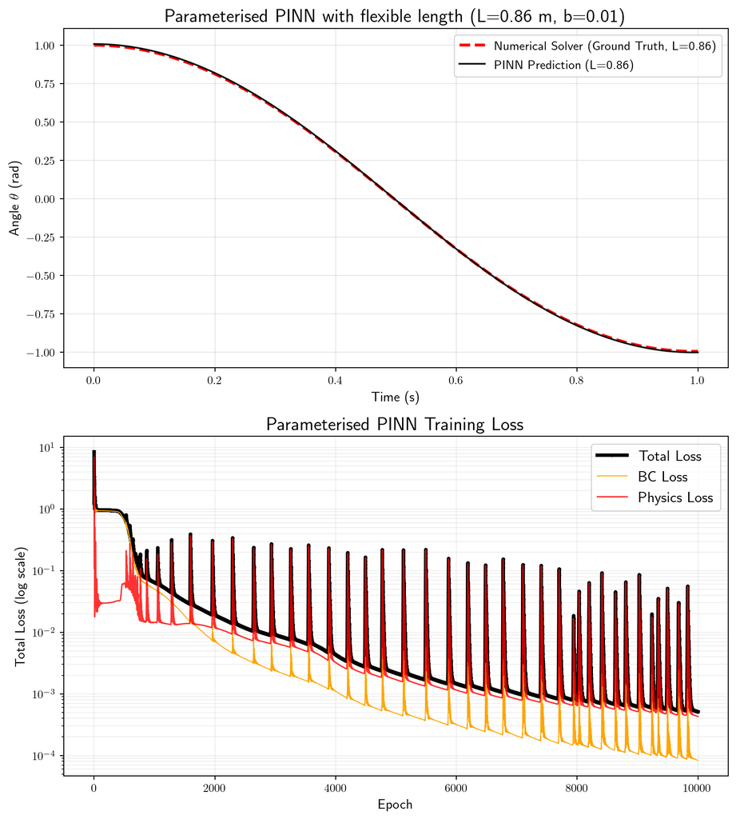

```python
fig, axes = plt.subplots(2, 1, figsize=(9, 10))

# ----------------------------------------------------------------------------
# Plot 1: PINN prediction vs numerical solution
ax1 = axes[0]
ax1.plot(
    t_num,
    theta_num,
    'r--',
    label=f"Numerical Solver (Ground Truth, L={L_test_val})",
    linewidth=2.5)
ax1.plot(
    t_pred.cpu().numpy(),
    theta_pred,
    'k-',
    label=f"PINN Prediction (L={L_test_val})",
    alpha=0.9)
ax1.set_title(
    f"Parameterised PINN with flexible length (L={L_test_val} m, b={b})",
    fontsize=16)
ax1.set_xlabel("Time (s)", fontsize=12)
ax1.set_ylabel(r"Angle $\theta$ (rad)", fontsize=12)
ax1.legend(fontsize=11)
ax1.grid(True, alpha=0.3)

# ----------------------------------------------------------------------------
# Plot 2: Training loss convergence
ax2 = axes[1]
ax2.plot(
    total_loss_history,
    marker='o',
    markersize=2,
    color='black',
    linewidth=3,
    label="Total Loss"
    )
ax2.plot(
    bc_loss_history,
    color='orange',
    linewidth=0.8,
    label="BC Loss")
ax2.plot(
    phys_loss_history,
    color='red',
    linewidth=1.2,
    alpha=0.8,
    label="Physics Loss")
ax2.set_yscale("log")
ax2.set_title("Parameterised PINN Training Loss", fontsize=16)
ax2.set_xlabel("Epoch", fontsize=12)
ax2.set_ylabel("Total Loss (log scale)", fontsize=12)
ax2.grid(True, which="both", linestyle="-", alpha=0.2)
ax2.legend(fontsize=13)

plt.tight_layout()
plt.show()
```

## Why Are There Spikes in the Loss?

The training loss plot above shows dramatic, regularly-spaced spikes that persist throughout training. There are several contributing factors:

**1. Gradient competition between loss terms (primary cause)**

The two losses (*i.e.*, BC loss and physics loss) pull the network in opposing directions. When Adam makes good progress minimising the physics residual, it can push the weights into a region where the boundary conditions are violated (and vice versa). With equal weighting ($\lambda = 1$ for both) and no adaptive balancing, these competing gradients periodically destabilise each other, producing the sawtooth pattern.

**2. Fixed collocation points (no stochastic smoothing)**

The 2,000 collocation points and 500 boundary points are sampled once before training and reused every epoch. There is no resampling. This means the loss landscape is deterministic and the optimiser can get trapped oscillating in narrow valleys. Periodic resampling of collocation points would introduce stochastic averaging that dampens these oscillations.

**3. Constant learning rate with Adam’s momentum**

Adam at a fixed `lr = 1e-3` accumulates momentum. When progress on one loss term builds up momentum, the resulting step can overshoot and spike the other loss. Without learning rate decay or gradient clipping, there is nothing to dampen these overshoots as training progresses.

**Possible mitigations:**

- **Resample collocation points** every $N$ epochs to smooth the loss landscape.
- **Learning rate scheduling** (e.g. cosine decay or `ReduceLROnPlateau`) to reduce step sizes as training progresses.
- **Adaptive loss weighting** (e.g. the method of Wang et al., 2021) so the two loss terms remain balanced.
- **Gradient clipping** (`torch.nn.utils.clip_grad_norm_`) to prevent large update steps.

# Evaluating across multiple pendulum lengths

For each $L$ value the code:

1. **Builds the PINN input:** creates a constant $L$ column with `torch.full_like` and concatenates it with the shared time grid to form a $(300, 2)$ input tensor.
2. **Queries the trained network:** a single `pinn(test_input)` forward pass (inside `torch.no_grad()`) returns $\hat{\theta}(t, L)$ for all 300 time points at that length.
3. **Computes the numerical reference:** `odeint` solves the pendulum ODE with $c_p = g/L_\text{val}$ for the same time grid, providing the ground truth $\theta(t)$ to compare against.
4. **Plots both curves** in the same colour (dashed for numerical, solid for PINN), so agreement between the two is immediately visible for each $L$.

Shorter pendulums ($L = 0.5$ m) oscillate faster because $c_p = g/L$ is larger, while longer ones ($L = 1.5$ m) oscillate more slowly. The plot shows that the PINN captures this frequency variation across the full range from a single training run.

```python
# Plot PINN predictions for multiple L values on the same graph
# No retraining needed, just change L_pred in the evaluation inputs

# all within training range
L_param_range   = np.linspace(L_min, L_max, 10).tolist()
t_range_pred     = torch.linspace(
    t_start, t_end, 300, device=device).view(-1, 1)

colors = plt.cm.viridis(np.linspace(0.15, 0.85, len(L_param_range)))

start_time_multi_pred = time.time()

L_param_pinn_pred_dict = {}

for L_val, col in zip(L_param_range, colors):

    # PINN prediction
    L_col   = torch.full_like(t_range_pred, L_val)

    # Concatenate t_range_pred and L_col to create input pairs (t, L_val)
    test_input     = torch.cat([t_range_pred, L_col], dim=1)

    # Evaluate the PINN at the new L value
    with torch.no_grad():
        pred = pinn(test_input).cpu().numpy()
        L_param_pinn_pred_dict[L_val] = pred

elapsed_time_multi_pred = time.time() - start_time_multi_pred
print("Multi-L PINN prediction complete in "
      + f"{elapsed_time_multi_pred:.4f} seconds.")
```

```
Multi-L PINN prediction complete in 0.0042 seconds.
```

```python
t_num_ext  = np.linspace(t_start, t_end, 300)

start_time_multi_num = time.time()

L_param_ode_num_dict = {}

for L_val, col in zip(L_param_range, colors):

    # Numerical ground truth at the same L value
    ode_sol = odeint(
        lambda s, t: [s[1], -(g / L_val)*np.sin(s[0]) - (b/m)*s[1]],
        [theta0, omega0], t_num_ext
    )

    L_param_ode_num_dict[L_val] = ode_sol[:,0]

elapsed_time_multi_ode = time.time() - start_time_multi_pred
print("Multi-L ODE computation complete in "
      + f"{elapsed_time_multi_ode:.4f} seconds.")
```

```
Multi-L ODE computation complete in 0.0095 seconds.
```

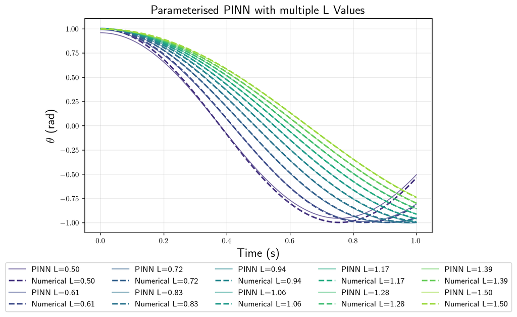

```python
fig, ax = plt.subplots(figsize=(9, 6))

colors = plt.cm.viridis(np.linspace(0.15, 0.85, len(L_param_range)))

for L_val, col in zip(L_param_range, colors):

    ax.plot(
        t_range_pred.cpu().numpy(),
        L_param_pinn_pred_dict[L_val],
        '-',
        color=col,
        linewidth=1.2,
        alpha=0.7,
        label=f'PINN L={L_val:.2f}')

    ax.plot(
        t_num_ext,
        L_param_ode_num_dict[L_val],
        '--', color=col, linewidth=2,
        label=f'Numerical L={L_val:.2f}')

ax.set_xlabel('Time (s)', fontsize=16)
ax.set_ylabel(r'$\theta$ (rad)', fontsize=16)
ax.set_title(
    'Parameterised PINN with multiple L Values',
    fontsize=16)
ax.legend(
    fontsize=11, ncol=5,
    loc='upper center', bbox_to_anchor=(0.5, -0.12))
ax.grid(True, alpha=0.3)
plt.tight_layout()
plt.show()
```

# Computational Time Comparison

The bar chart below compares the wall-clock time for each stage of the workflow. PINN training (10,000 epochs) is by far the most expensive step, but it is a **one-time cost**. Once trained, the parameterised PINN can predict $\hat{\theta}(t, L)$ at any new $L$ value with a single forward pass through the network without requiring any no ODE integration.

The key insight is in the prediction columns: querying the trained PINN at 10 different $L$ values takes roughly the same time as querying it at one, because each evaluation is just a cheap matrix multiplication through the network. By contrast, the ODE solver must re-integrate the full system from scratch for every new $L$ value, so its cost scales linearly with the number of test lengths.

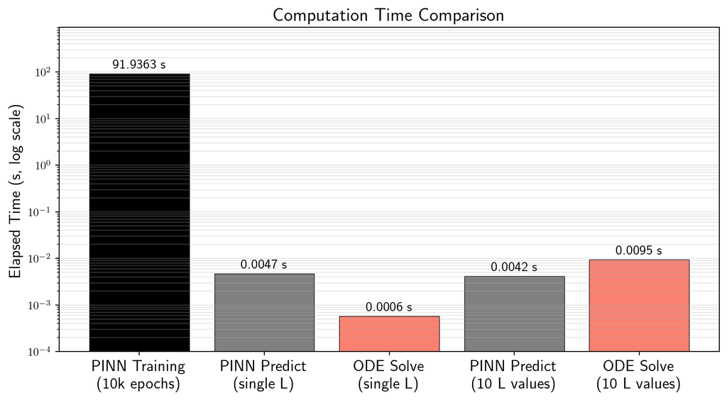

```python
labels = [
    "PINN Training\n(10k epochs)",
    "PINN Predict\n(single L)",
    "ODE Solve\n(single L)",
    "PINN Predict\n(10 L values)",
    "ODE Solve\n(10 L values)",
]

times = [
    elapsed_time_pinn_training,
    elapsed_time_pinn_single_L_pred,
    elapsed_time_ode_single_L,
    elapsed_time_multi_pred,
    elapsed_time_multi_ode,
]

bar_colors = ["black", "grey", "salmon", "grey", "salmon"]

fig, ax = plt.subplots(figsize=(9, 5))
bars = ax.bar(
    labels,
    times,
    color=bar_colors,
    edgecolor="black",
    linewidth=0.5)

for bar, t in zip(bars, times):
    ax.text(
        bar.get_x() + bar.get_width() / 2,
        bar.get_height() * 1.15,
        f"{t:.4f} s",
        ha="center",
        va="bottom",
        fontsize=12,
    )

ax.set_yscale("log")
ax.set_ylabel("Elapsed Time (s, log scale)", fontsize=14)
ax.set_title("Computation Time Comparison", fontsize=16)
ax.set_ylim(bottom=1e-4, top=max(times)*10)
ax.tick_params(axis="x", labelsize=14)
ax.grid(axis="y", alpha=0.3, which="both")
plt.tight_layout()
plt.show()
```

# References

1. Francis Fernandes (2026). Mastering Dynamic PINNs.
2. Dao, Duc Long. “Experimental evaluation of damping models for a nonlinear pendulum system.” Physics Education 58, no. 5 (2023): 055003.